# HW 1: CONJ 620 W22

M. Kathrina Onate

Due 1/11/22

## Directions

- Please upload your homework to Sakai. Upload both your .Rmd code file and the knitted .html file.
  - If you do not upload the html file of your knitted Rmd file, 20 (out of 100) points will be deducted from your homework grade. *If there is an error with code in a code chunk that is preventing the file from knitting, then comment out that code and make a note that it’s not running.*
- The questions are numbered 1-22. Please do not use `(@)` in your edits to this file so that the exercise numbering does not change!
- For each question, make sure to include all code and resulting output in the html file to support your answers. Answers to questions do not need be lengthy, but thoughtful and descriptive.
- Please only use techniques covered in the first week to answer these questions. In particular, we have not covered data wrangling yet.
- For the data visualizations, you do not have change the default colors or themes or legends. However, you are of course welcome to do so if you like.

> Tip: It is a good idea to try kitting your document from time to time as you go along! Note that knitting automatically saves your Rmd file and knitting frequently helps you catch your errors more quickly.

## Load packages & data

- Below is code to load the packages we need for this assignment. There is a new package `palmerpenguins` that you will also need to first install (use commented out code).
  - Notice that when loading the `tidyverse` package, that `ggplot2` is one of the packages that gets loaded. Thus, we don’t need to separately load `ggplot2`.
- Note that the R chunk includes `message = FALSE` in the first line. This is so that the messages that appear when loading the packages don’t show up in your knitted html file. The messages will still appear within the R console when running it within RStudio.

```r
library(tidyverse)

# install.packages("palmerpenguins")
library(palmerpenguins)
```

# Penguins data exploration

Explore the `penguins` dataset using the base R commands from Day 1.

1. **How many observations and variables are included in this dataset?**  
   Correct? I understand that “names(penguins)” is on question 1, but I didn’t expect it to be listed for this question… did we need it? And the way I was able to distinguish what the variables were to was to type out head(penguins) on my console, but not this R markdown. I guess next time I should be clearer where I find my data?

```r
data(penguins)
names(penguins)
```

```
## [1] "species"           "island"            "bill_length_mm"
## [4] "bill_depth_mm"     "flipper_length_mm" "body_mass_g"
## [7] "sex"               "year"
```

**Answers from HW 1, Part 1:**  
*(Note to self: observations mean rows and variables mean columns.)* There are 8 variables and 344 observations in the `penguins` dataset.

2. **Give a brief description of each variable.** In particular:
   - Based on the variable name (& that the name of the dataset is penguins), what is your best guess as to what the variable represents?
   - What is the variable type? Give both the R variable type and classify the variable as being discrete, continuous, ordinal, or nominal (see Section 1.2.2 (pgs. 15-16) of Vu & Harrington).
   - Give a brief summary of the variable. Pretend you are describing the data to someone who is not familiar with the dataset.  
     Is this correct, too? I guess I was also a little confused here as well. First: I realize now that there’s a difference between variable type versus variable classification. I didn’t quite know the difference so I wrote my answer only for one as I thought they were one in the same. Next time I’ll include ‘str(penguins)’ for more details.  
     Second: I also didn’t quite understand with what you meant by “give brief summary of the variable.” In my head, it seemed better to describe it in a paragraph.

```r
summary(penguins)
```

```
##       species          island    bill_length_mm  bill_depth_mm
##  Adelie   :152   Biscoe   :168   Min.   :32.10   Min.   :13.10
##  Chinstrap: 68   Dream    :124   1st Qu.:39.23   1st Qu.:15.60
##  Gentoo   :124   Torgersen: 52   Median :44.45   Median :17.30
##                                  Mean   :43.92   Mean   :17.15
##                                  3rd Qu.:48.50   3rd Qu.:18.70
##                                  Max.   :59.60   Max.   :21.50
##                                  NA's   :2       NA's   :2
##  flipper_length_mm  body_mass_g       sex           year
##  Min.   :172.0     Min.   :2700   female:165   Min.   :2007
##  1st Qu.:190.0     1st Qu.:3550   male  :168   1st Qu.:2007
##  Median :197.0     Median :4050   NA's  : 11   Median :2008
##  Mean   :200.9     Mean   :4202                Mean   :2008
##  3rd Qu.:213.0     3rd Qu.:4750                3rd Qu.:2009
##  Max.   :231.0     Max.   :6300                Max.   :2009
##  NA's   :2         NA's   :2
```

**Answers from HW 1, Part 1:**  
Each variable (or column) represents details about each penguin, whether its species type, island, year (most likely the year when the penguin was born), sex, and morphology–specifically a penguin’s bill length and depth, its flipper length, and its body mass (by grams). “Species” and “island” are considered as **nominal categorical** values because they are not numbers (hence “categorical”), but the variable value doesn’t have a ranking (“nominal”). On the other hand, the morphological attributes I listed above are considered as **numerical** variables. But, “year” variable is specifically a *discrete* numerical variable because you can count it (it’s arguably not measurable because it doesn’t change when it’s set… I guess), while the others are *continuous* numerical variables because continuous values need to be measured (so there could be decimals).

# Data viz: what story are the data telling us?

## Scatterplots

### Bill length (y-axis) vs. the bill depth (x-axis)

*Note: we usually say **y-variable vs. x-variable** when referring to a scatterplot, which is opposite of thinking about (x,y).*

3. **Make a scatterplot of the bill length (y-axis) vs. the bill depth (x-axis).**
   - Include some level of transparency of the points.
   - Label the axes with descriptive “nice looking” names that are not the original variable names.
   - Add a title to the plot.

Correct. I did something extra where I put an r^2 line (not necessary), but I wanted it because I needed to be able to see if there was even a *a linear relationship* between bill length and depth

**Answers from HW 1, Part 1:**

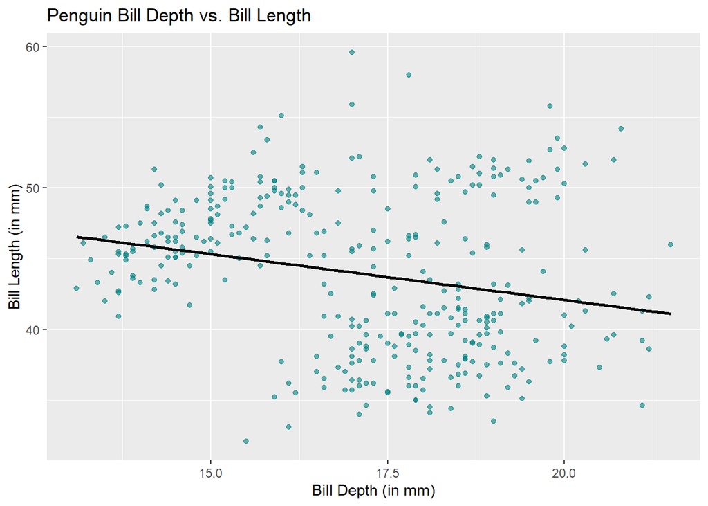

```r
library(ggplot2) #make graphs
library(ggridges) #MOARE fun graph options

#Scatter plot
ggplot(data = penguins,
       aes(x = bill_depth_mm, y = bill_length_mm)) +

  geom_point(color = "#008080",
             alpha = 0.6,
             show.legend = FALSE) +

  labs(x = "Bill Depth (in mm)",
       y = "Bill Length (in mm)",
       title = "Penguin Bill Depth vs. Bill Length") +

#Adding r^2 function to better observe linear relationship
  geom_smooth(method = "lm",
              color = "black",
              se = FALSE)
```

4. **Is the linear relationship between these variables best described as being weak, moderate, or strong? Also, is it positive, negative, or neither?**  
   Correct. Same answer as solutions, just with r^2 line.

**Answers from HW 1, Part 1:** Based off of the r^2 line drawn, it seems that the linear relationship between bill depth and length is rather weak, and somewhat negative.

## Distribution shapes

- We will now explore the distribution shapes of the quantitative variables.
- When describing distribution shapes, consider whether they are symmetric, uniform, skewed left or right, bimodal, multimodal, or some combination there of.

### Flipper lengths

5. **Make a histogram and a density plot for the flipper length.**  
   Correct. No issues here, I just made mine with more colors because it was easier for me to somewhat interpret the data if there were colorful visuals.

**Answers from HW 1, Part 1:**

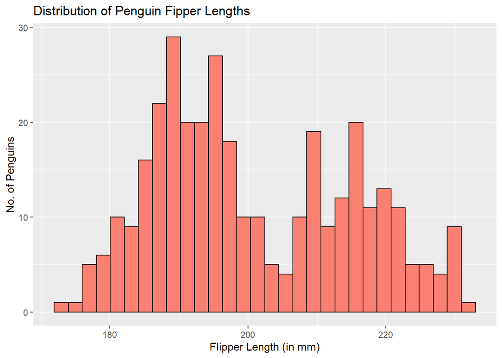

```r
#Histogram
ggplot(data = penguins,
       aes(x = flipper_length_mm)) +

  geom_histogram(color = "#000000",
                 fill = "#fa8072",
                 show.legend = FALSE) +

  labs(x = "Flipper Length (in mm)",
       y = "No. of Penguins",
       title = "Distribution of Penguin Fipper Lengths")
```

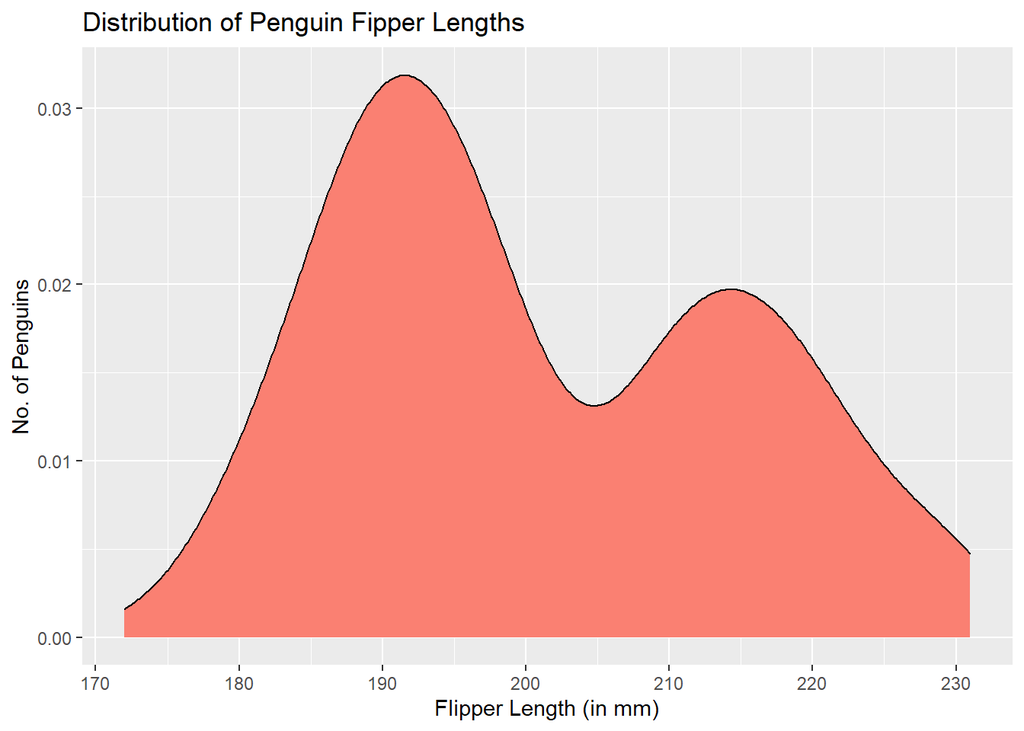

```r
#Density Plot
ggplot(data = penguins,
       aes(x = flipper_length_mm)) +

  geom_density(color = "#000000",
                 fill = "#fa8072",
                 show.legend = FALSE) +

  labs(x = "Flipper Length (in mm)",
       y = "No. of Penguins",
       title = "Distribution of Penguin Fipper Lengths")
```

6. **Describe the distribution shape. If the distribution has modes (peaks), what variables do you think might be associated with them?**  
   Correct. Same answer.

**Answers from HW 1, Part 1:** Based on both the histogram and density plot, it looks as if there is a mild binomial distribution of flipper lengths in these penguins. This variable could be associated by sex.

### Body mass

7. **Make a histogram and a density plot for the body mass.**  
   Correct. Same answer.

**Answers from HW 1, Part 1:**

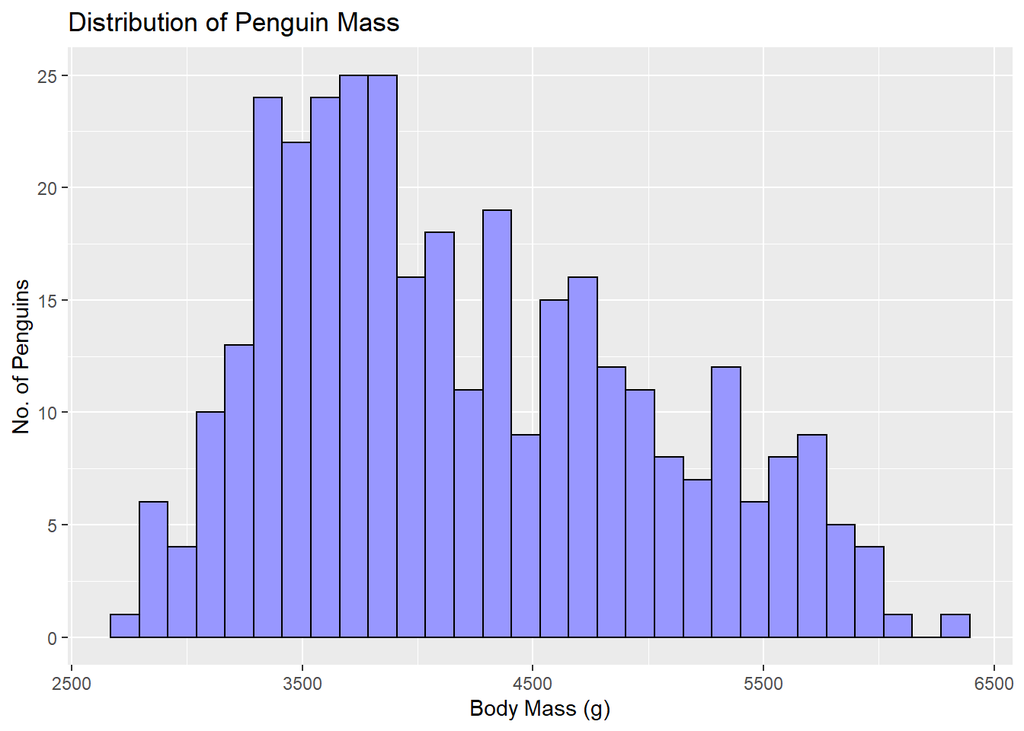

```r
#Histogram
ggplot(data = penguins,
       aes(x = body_mass_g)) +

  geom_histogram(color = "#000000",
                 fill = "#9897FF",
                 show.legend = FALSE) +

  labs(x = "Body Mass (g)",
       y = "No. of Penguins",
       title = "Distribution of Penguin Mass")
```

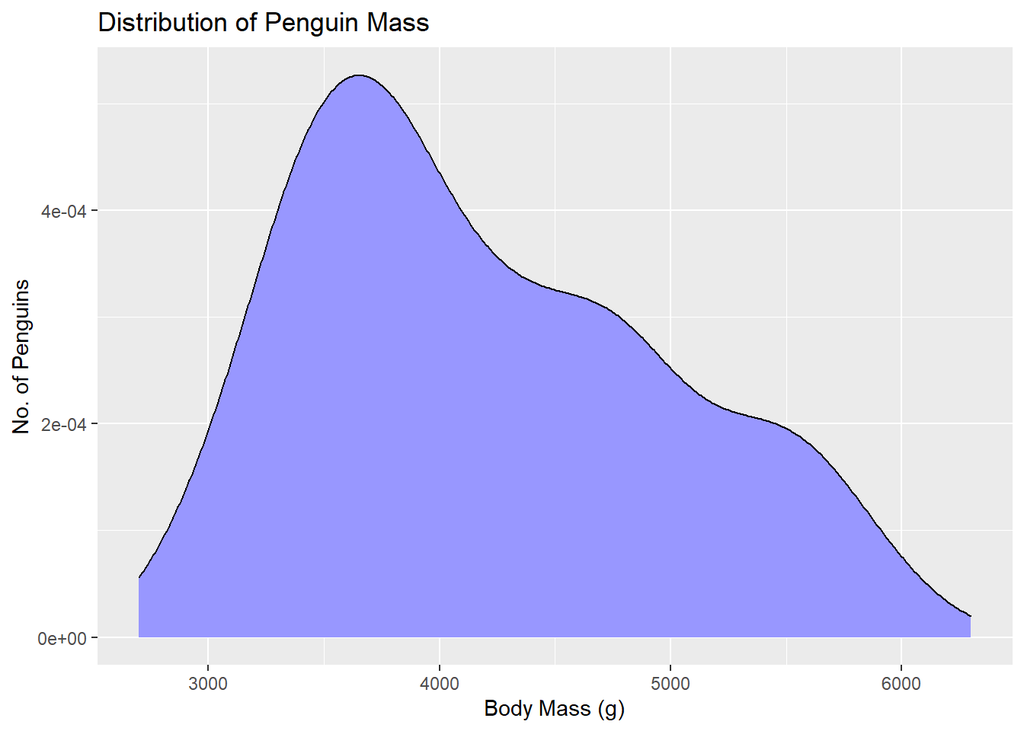

```r
#Density Plot
ggplot(data = penguins,
       aes(x = body_mass_g)) +

  geom_density(color = "#000000",
                 fill = "#9897FF",
                 show.legend = FALSE) +

  labs(x = "Body Mass (g)",
       y = "No. of Penguins",
       title = "Distribution of Penguin Mass")
```

8. **Describe the distribution shape. If the distribution has modes (peaks), what variables do you think might be associated with them?**  
   Woops. I meant “right-skewed”, not “left-skewed”. It looks left when I see it from my POV, but it is right-skewed.  
   The body masses have a skewed right distribution. There is one main peak.

### Going deeper with flippers

Let’s explore the distributions of *flipper lengths* by sex and species.

9. **Make a figure with density plots to compare the distribution shapes by sex. What does this plot tell you both about the shapes and comparing the values between groups?**  
   Correct. Similar answer.

**Answers from HW 1, Part 1:**

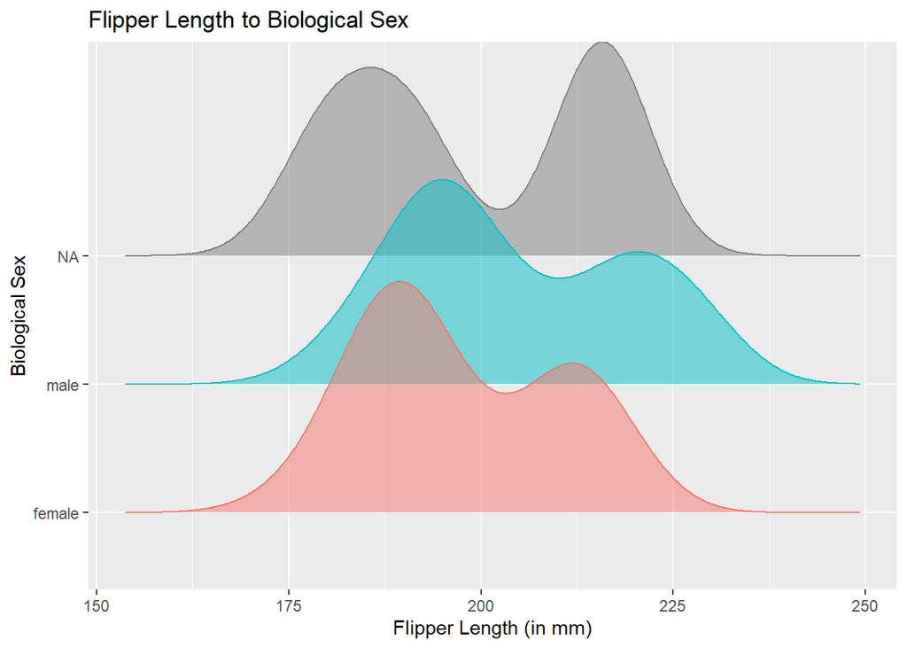

```r
#Density Plot
ggplot(data = penguins,
       aes(y = sex,
           x = flipper_length_mm,
       color = sex,
       fill = sex)) +

  geom_density_ridges(
    alpha = 0.5,
   show.legend = FALSE) +

  labs(x = "Flipper Length (in mm)",
       y = "Biological Sex",
       title = "Flipper Length to Biological Sex")
```

I initially mentioned earlier that flipper length may be dependent on biological sex. And although this graph shows that males have longer flipper lengths, the binomial distribution between males and females is still there.

### Color coding bill length (y-axis) vs. the bill depth (x-axis)

10. **Create two new scatterplots, where one color codes the dots by island and the other by species.**  
    Correct. Similar answer.

**Answers from HW 1, Part 1:**

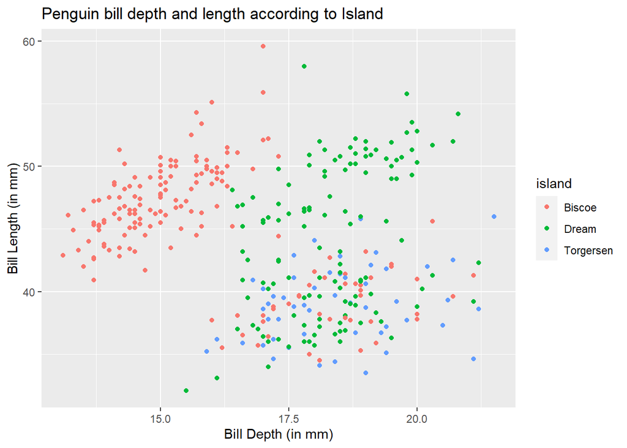

```r
#Scatterplot 1: by island
ggplot(data = penguins,
       aes(x = bill_depth_mm,
           y = bill_length_mm,
           color = island)) +

  geom_point() +

  labs(x = "Bill Depth (in mm)",
       y = "Bill Length (in mm)",
       title = "Penguin bill depth and length according to Island")
```

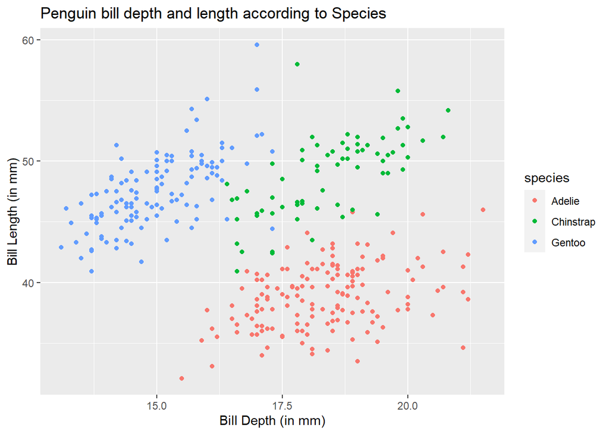

```r
#Scatterplot 2: by species
ggplot(data = penguins,
       aes(x = bill_depth_mm,
           y = bill_length_mm,
           color = species)) +

  geom_point() +

  labs(x = "Bill Depth (in mm)",
       y = "Bill Length (in mm)",
       title = "Penguin bill depth and length according to Species")
```

11. **Is the relationship between bill length and depth stronger within islands or within species? Describe how you came to this conclusion. Again, assume that you are talking to someone that doesn’t see the plot.**  
    Correct. Similar answer.

**Answers from HW 1, Part 1:** I think that the relationship between bill size (i.e. length and depth) are more strongly associated with species than with island. There’s *an overlap of penguins with similar bill sizes that happen to come from different islands*. However, you do not see the same overlap in the Species scatterplot. In fact, you don’t really see an overlap of bill size to species.

### Species vs. island?

12. **Take another look at the two color-coded scatterplots. Based on these scatterplots, which species tend to live on which islands?**  
    Similar answer.

**Answers from HW 1, Part 1:** Gentoo species generally live on Biscoe island; Chinstrap species generally live on Dream island; and, Adelie species seem to live equally among the three islands: Biscoe, Dream, and Torgersen.

### Back to flipper lengths…

13. **Make a figure with density plots of the flipper lengths to compare the distribution shapes by species. What does this plot tell you both about the shapes and comparing the values between groups?**  
    Correct. Similar answer.

**Answers from HW 1, Part 1:**

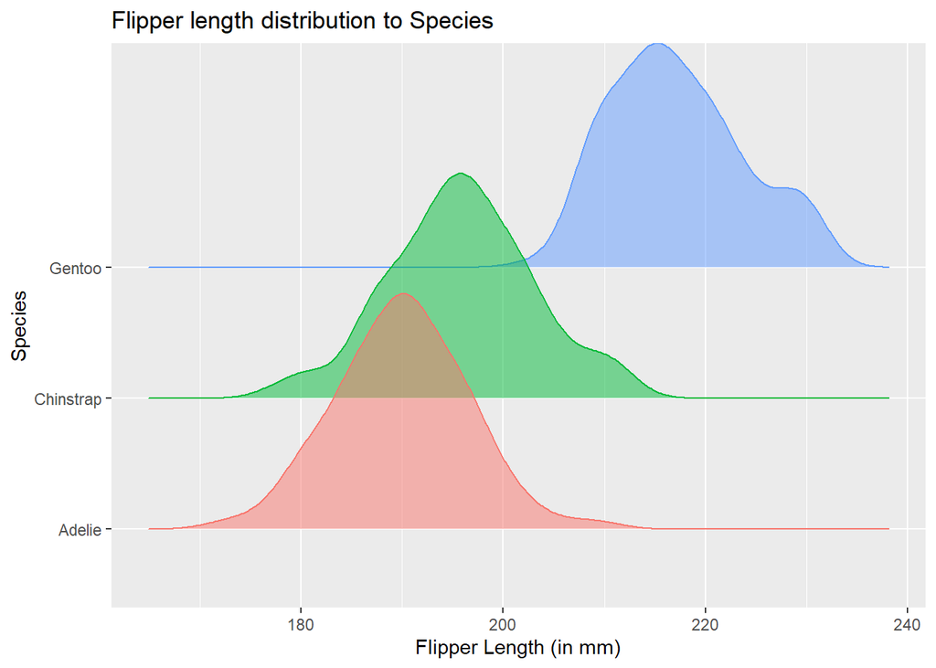

```r
#Make a density plot comparing flipper lengths to species
ggplot(data = penguins,
       aes(x = flipper_length_mm,
           y = species,
           color = species,
           fill = species)) +

  geom_density_ridges(
    alpha = 0.5,
   show.legend = FALSE) +

  labs(x = "Flipper Length (in mm)",
       y = "Species",
       title = "Flipper length distribution to Species")
```

It seems that the Gentoo species on average has a longer flipper length than both the Adelie and Chinstrap species; the Adelie and Chinstrap species are closer in range, with the Gentoo species having a mean that looks to be greater or equal to 75th percentile of the Adelie species.

14. **Make a figure with density plots of the flipper lengths to compare the distribution shapes by both sex and species.** *Hint: facet!*  
    Correct. Similar answer as to the solutions.

**Answers from HW 1, Part 1:**

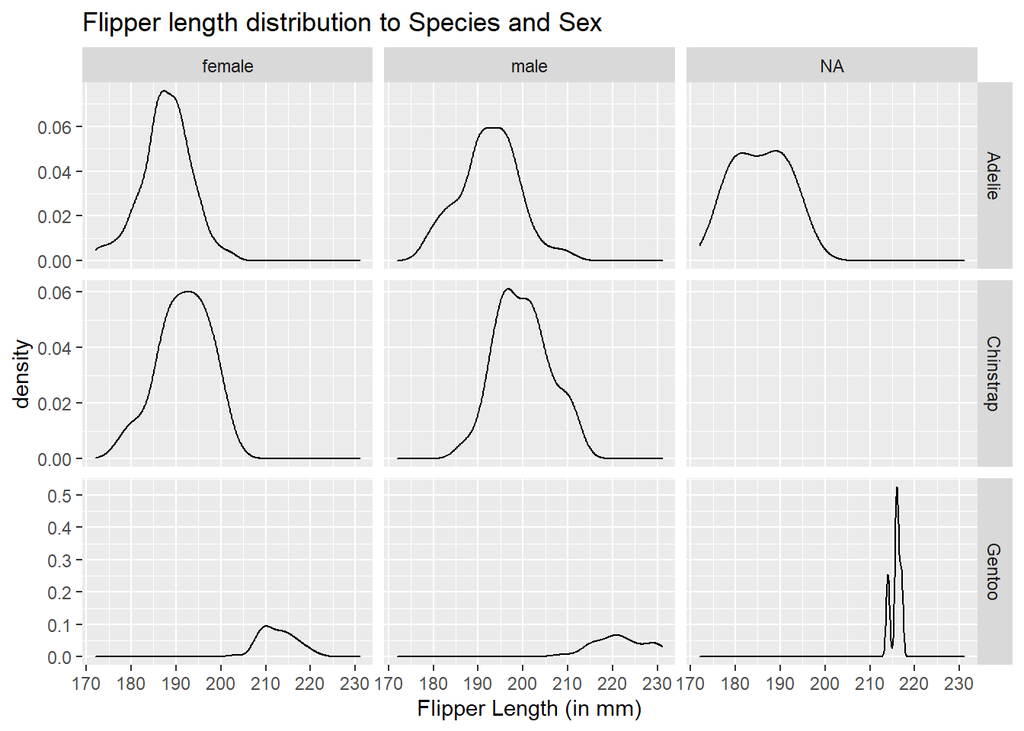

```r
#Make a density plot comparing flipper lengths to species AND sex
ggplot(data = penguins,
       aes(x = flipper_length_mm)) +

  geom_density(
    alpha = 0.5,
   show.legend = FALSE) +

  facet_grid(rows = vars(species),
             cols = vars(sex),
             scales = "free_y") +

  labs(x = "Flipper Length (in mm)",
       title = "Flipper length distribution to Species and Sex")
```

## Boxplots

15. **Make a figure of boxplots for flipper lengths for the different sexes.**  
    Correct. Similar answer as to the solutions, but I just added jitter to see how data is spread among the box plot.

**Answers from HW 1, Part 1:**

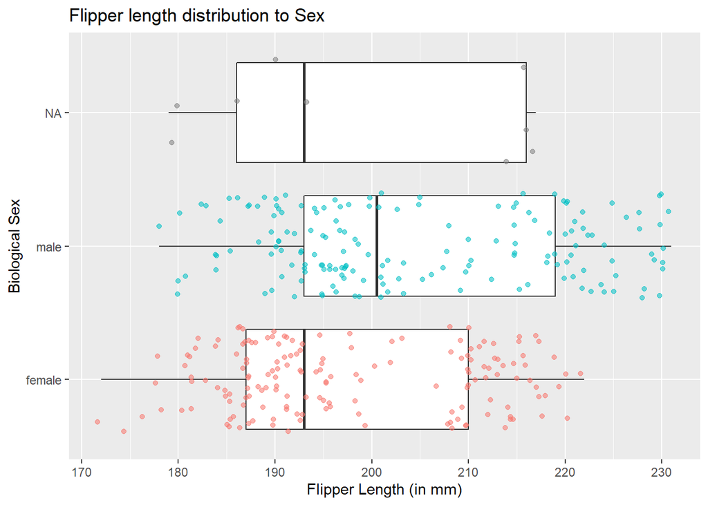

```r
#Box plot comparing flipper lengths to sex
ggplot(data = penguins,
       aes(x = flipper_length_mm,
           y = sex)) +

  geom_boxplot() +

  labs(x = "Flipper Length (in mm)",
       y = "Biological Sex",
       title = "Flipper length distribution to Sex") +

  geom_jitter(
    aes(color = sex,
        alpha = 0.3),
    show.legend = FALSE)
```

16. **Build on your previous graph to add faceting by species.**  
    Correct. Similar answer as to the solutions, but the answer key had y = sex, which may have helped with the graph visually.

**Answers from HW 1, Part 1:**

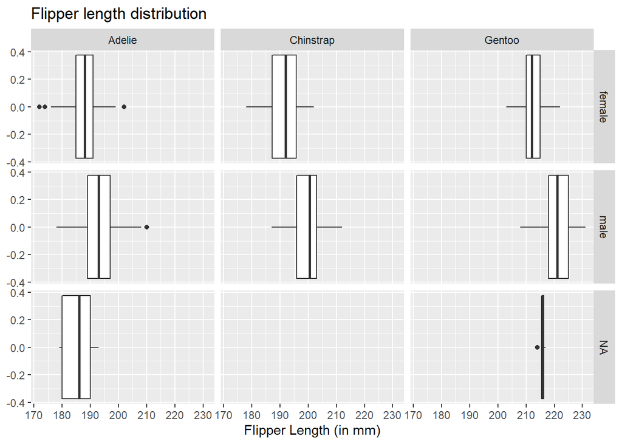

```r
#Box plot comparing flipper lengths to sex + species
ggplot(data = penguins,
       aes(x = flipper_length_mm)) +

  geom_boxplot() +

  facet_grid(
    rows = vars(sex),
    cols = vars(species)) +

  labs(x = "Flipper Length (in mm)",
       title = "Flipper length distribution")
```

## Bargraphs

Let’s now explore the categorical variables.

18. **Make a bargraph for the species. Which species is the most common? Least common?**  
    Correct. Similar answer as to the solutions.

**Answers from HW 1, Part 1:**

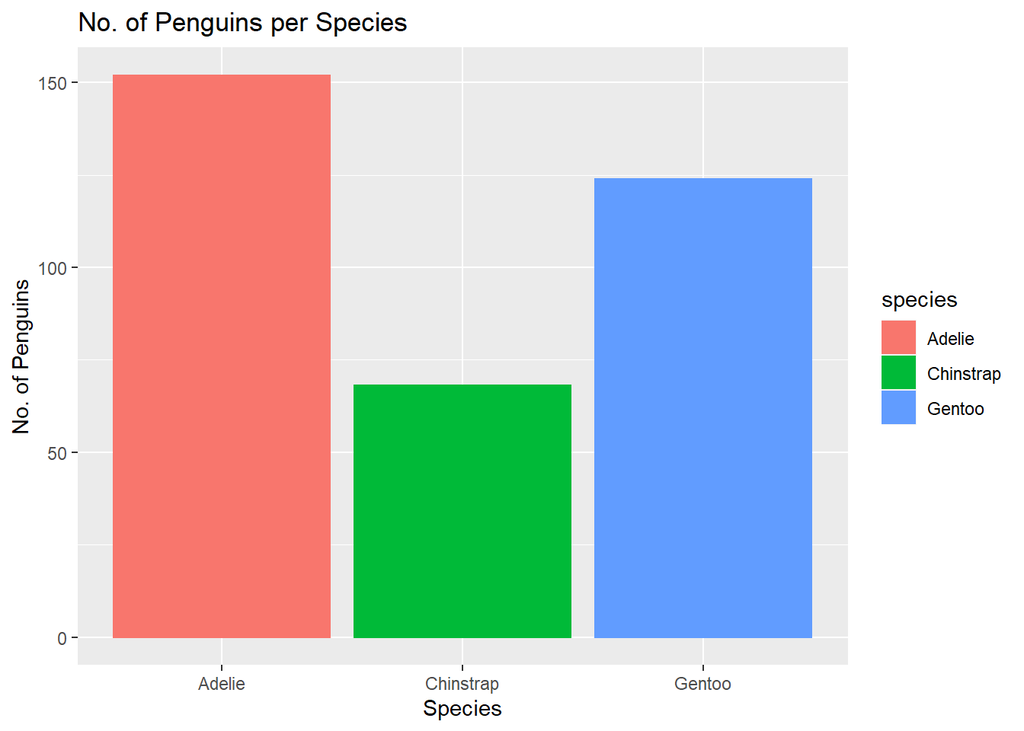

```r
#Species bargraph
ggplot(data = penguins,
       aes(x = species,
           color = species,
           fill = species,
           show.legend = FALSE)) +

  geom_bar() +

  labs(x = "Species",
       y = "No. of Penguins",
       title = "No. of Penguins per Species")
```

It seems that the Adelie species are the most common species, and the Chinstrap species are the least common.

19. **Make a bargraph for the islands. Which island is the most common? Least common?**  
    Correct. Similar answer as to the solutions.

**Answers from HW 1, Part 1:**

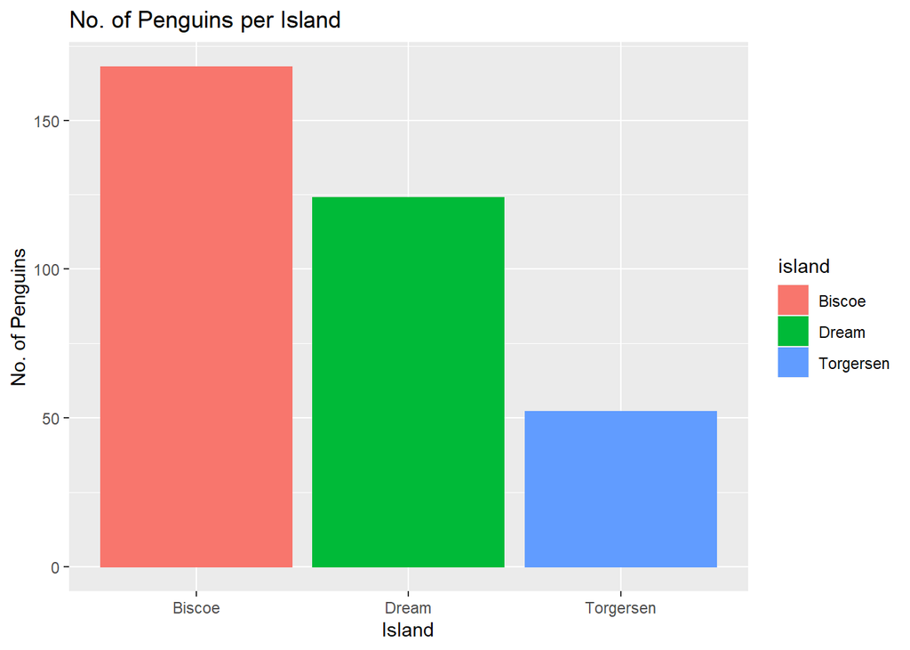

```r
#Island bargraph
ggplot(data = penguins,
       aes(x = island,
           color = island,
           fill = island,
           show.legend = FALSE)) +

  geom_bar() +

  labs(x = "Island",
       y = "No. of Penguins",
       title = "No. of Penguins per Island")
```

Biscoe island has the most penguins; Torgersen island has the least penguins.

### Stacked bargraphs

20. **Make a bargraph for the species stacked by sex. Was sex approximately evenly distributed within each species, or was one sex more common for some or all species?**  
    Correct. Similar answer as to the solutions. In my case, I made the second graph because I wanted to see sex distribution among the species, so I went by percentage/position = “fill”.

**Answers from HW 1, Part 1:**

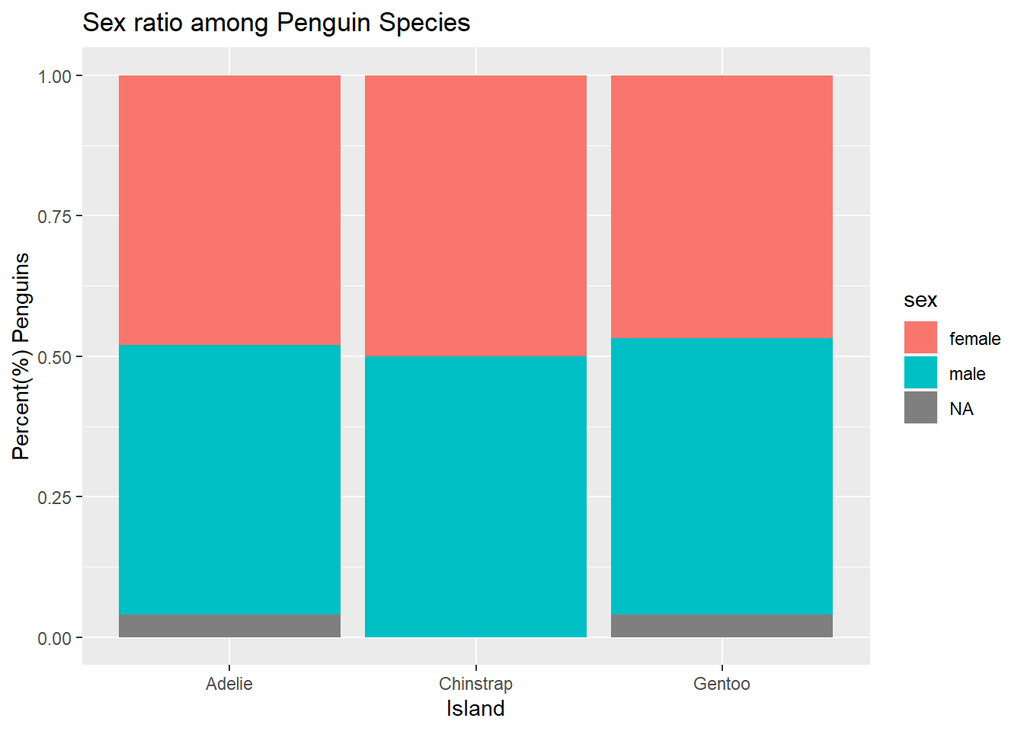

```r
#Species bargraph + sex
ggplot(data = penguins,
       aes(x = species,
           fill = sex)) +

  geom_bar(position = "fill") +

  labs(x = "Island",
       y = "Percent(%) Penguins",
       title = "Sex ratio among Penguin Species")
```

Sex seems equally distributed among the species.

21. **Make a bargraph for the islands stacked by species. What does this plot tell us about the species inhabitants of each of the islands?**  
    Correct. Similar to the previous question, I made the second graph because I wanted to see species distribution among the islands, so I went by percentage/position = “fill”. But the answer is the same. It’s fun seeing the number of ways you can get to the same answer.

**Answers from HW 1, Part 1:**

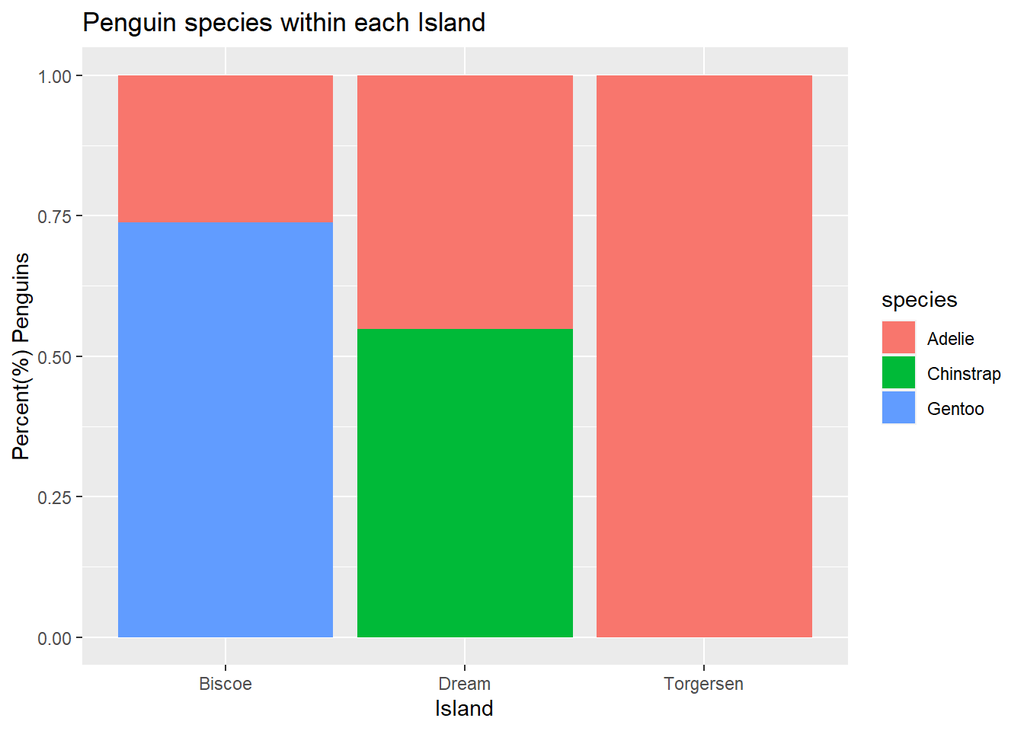

```r
#Island bargraph + species
ggplot(data = penguins,
       aes(x = island,
           fill = species)) +

  geom_bar(position = "fill") +

  labs(x = "Island",
       y = "Percent(%) Penguins",
       title = "Penguin species within each Island")
```

Chinstrap species solely live on Dream island; Gentoo species solely live on Biscoe island; but, Adelie species live on all three islands.

22. **Make various bargrpahs (at least two) to explore the year variable. Based on your figures, what is your guess for how the data were collected over time? I.e. were different species and islands targeted in different years, or were they all targeted over time?**  
    I pretty much did the same graphs as shown in the solutions, however I concluded more *what type* of study this was (longitudinal) that **focused on more the ecology of the islands**, whereas the solutions answered this if the penguin number changed over time. I guess it’s the same idea, worded differently?

**Answers from HW 1, Part 1:**

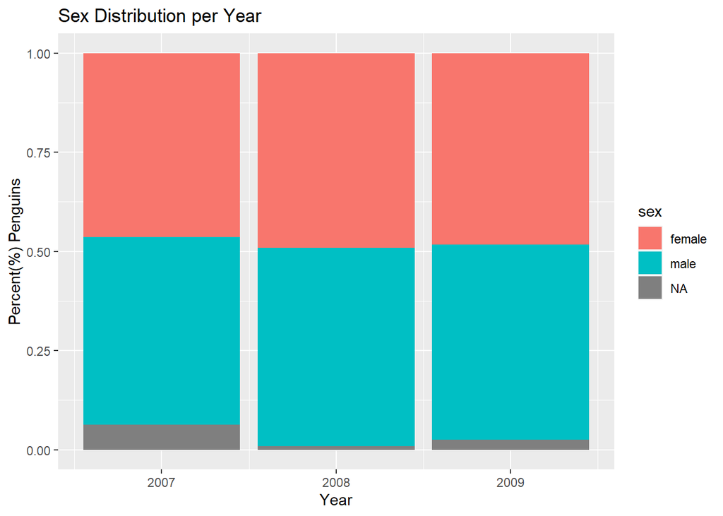

```r
#Bargraphs w/ year

#Sex Distribution per Year
ggplot(data = penguins,
       aes(x = year,
           fill = sex)) +

  geom_bar(position = "fill") +

  labs(x = "Year",
       y = "Percent(%) Penguins",
       title = "Sex Distribution per Year")
```

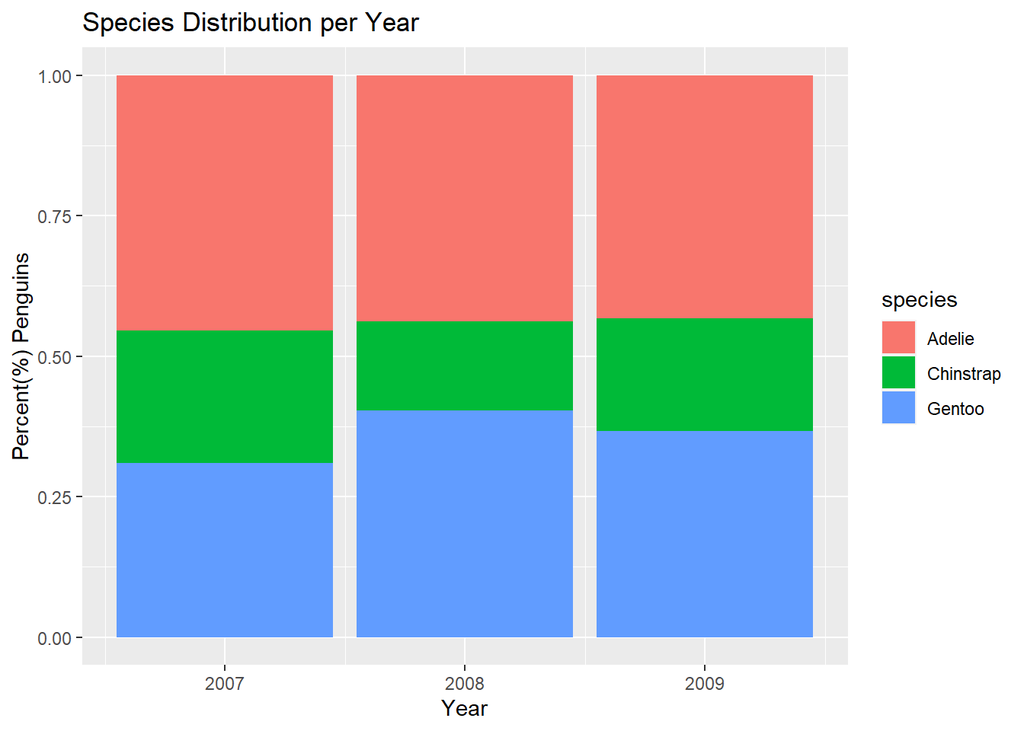

```r
#Species Distribution per Year
ggplot(data = penguins,
       aes(x = year,
           fill = species)) +

  geom_bar(position = "fill") +

  labs(x = "Year",
       y = "Percent(%) Penguins",
       title = "Species Distribution per Year")
```

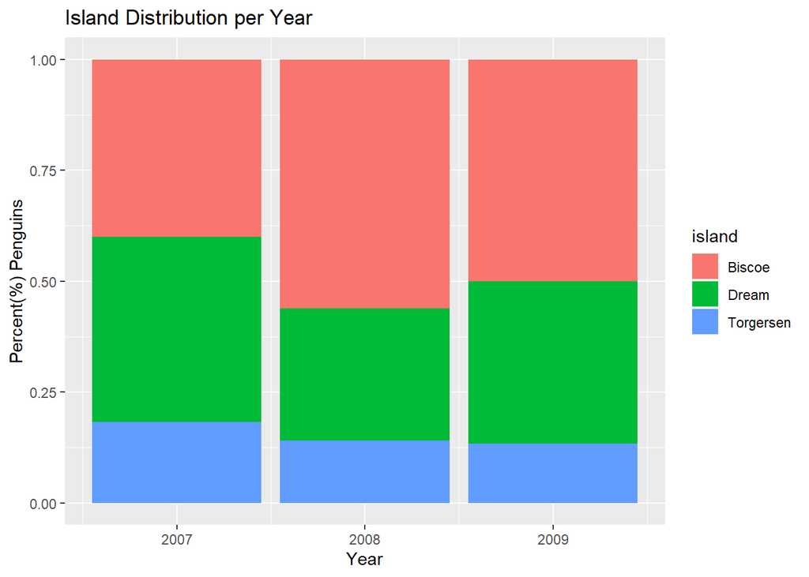

```r
#Island Distribution per Year
ggplot(data = penguins,
       aes(x = year,
           fill = island)) +

  geom_bar(position = "fill") +

  labs(x = "Year",
       y = "Percent(%) Penguins",
       title = "Island Distribution per Year")
```

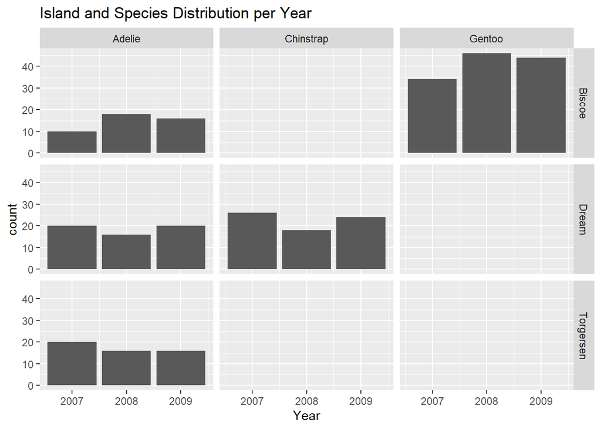

```r
#Combined data
ggplot(data = penguins,
       aes(x = year)) +

  geom_bar() +

  facet_grid(rows = vars(island),
             cols = vars(species)) +

  labs(x = "Year",
       title = "Island and Species Distribution per Year")
```

First off, the graph that displayed this information best is the last graph, due to its facet rendering. Now, if we recalled earlier, both Chinstrap and Gentoo species live in their respective islands only (Dream and Biscoe), while the Adelie species live on all three islands. Based off of the last graph, the data collected shows that all islands were targeted over time. So, this is a longitudinal study of all three islands and how each penguin species change (whether by population/island, sex/island, size, etc) over time.